# R Notebook

This notebook is created to answer all questions in Assignment 1 of the course Data Analaysis and Visualisation. It’s made by Cedric Gevers (8051003) and Vivian van Oosten (6395929) of group 3.

For this assignment, we looked through Kaggle for a suitable dataset. We found quite a few nice ones, but we were particularly interested in the wine dataset. It includes over 1500 wines with their chemical properties and a professionally determined quality between 3 and 8. One of the Kaggle challenges associated with this dataset was to predict the quality of the wine based on the chemical properties listed in the dataset. We decided to take up the challenge and see what our recently acquired data-skills could do for this dataset. Thus, our research question is:

How can we predict the quality of wine based on its chemical properties?

First we load the necessary libraries.

```r
library(tidyverse)
library(ggplot2)
library(GGally)
library(viridis)
library(scales)
library(dplyr)
library(magrittr)
library(mvtnorm)
library(ISLR)
set.seed(123)
```

We read in the dataframe.

```r
wine  <- read.csv('winequality-red.csv')
show(wine)
```

| fixed.acidity | volatile.acidity | citric.acid | residual.sugar | chlorides | free.sulfur.dioxide | total.sulfur.dioxide | density | pH | sulphates | alcohol | quality |
| --- | --- | --- | --- | --- | --- | --- | --- | --- | --- | --- | --- |
| 7.4 | 0.700 | 0.00 | 1.90 | 0.076 | 11.0 | 34 | 0.99780 | 3.51 | 0.56 | 9.4 | 5 |
| 7.8 | 0.880 | 0.00 | 2.60 | 0.098 | 25.0 | 67 | 0.99680 | 3.20 | 0.68 | 9.8 | 5 |
| 7.8 | 0.760 | 0.04 | 2.30 | 0.092 | 15.0 | 54 | 0.99700 | 3.26 | 0.65 | 9.8 | 5 |
| 11.2 | 0.280 | 0.56 | 1.90 | 0.075 | 17.0 | 60 | 0.99800 | 3.16 | 0.58 | 9.8 | 6 |
| 7.4 | 0.700 | 0.00 | 1.90 | 0.076 | 11.0 | 34 | 0.99780 | 3.51 | 0.56 | 9.4 | 5 |
| 7.4 | 0.660 | 0.00 | 1.80 | 0.075 | 13.0 | 40 | 0.99780 | 3.51 | 0.56 | 9.4 | 5 |
| 7.9 | 0.600 | 0.06 | 1.60 | 0.069 | 15.0 | 59 | 0.99640 | 3.30 | 0.46 | 9.4 | 5 |
| 7.3 | 0.650 | 0.00 | 1.20 | 0.065 | 15.0 | 21 | 0.99460 | 3.39 | 0.47 | 10.0 | 7 |
| 7.8 | 0.580 | 0.02 | 2.00 | 0.073 | 9.0 | 18 | 0.99680 | 3.36 | 0.57 | 9.5 | 7 |
| 7.5 | 0.500 | 0.36 | 6.10 | 0.071 | 17.0 | 102 | 0.99780 | 3.35 | 0.80 | 10.5 | 5 |

[output cut: 990 more lines]

While exploring the data, we found that for a lot of the variables, there didn’t seem to be a correlation between the chemical property and the quality of the wine. For the alcohol level and the volatile acidity of the wine, there did seem to be a correlation. We see lighter colors toward the top left of the plot, and darker colors in the bottom right. This does not fully answer our research question, but shows that these variables in part could explain the quality of the wine. For this visualisation, we have filtered out one outlier of the volatile acidity that made the other points unnecessarily close together. Without losing too much data, we have a bigger and more clear plot.

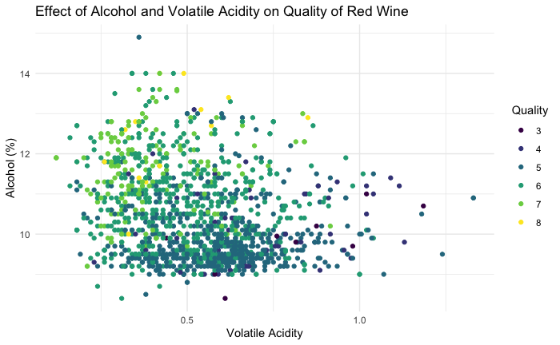

```r
wine_plot <- filter(wine, volatile.acidity < 1.5)
ggplot(wine_plot , mapping = aes( y = `alcohol`, x = `volatile.acidity`, color = as.factor(quality))) +
  geom_point() +
  scale_color_viridis_d(name = 'Quality') +
  labs(
    y = 'Alcohol (%)',
    x = 'Volatile Acidity',
    title = 'Effect of Alcohol and Volatile Acidity on Quality of Red Wine'
  ) +
  theme_minimal()
```

We try to filter out the missing data for our output variable, but there were none.

```r
wine_true <- wine %>% filter(!is.na(quality))
nrow(wine)
```

```
[1] 1599
```

```r
nrow(wine_true)
```

```
[1] 1599
```

Now we are going to split our wine dataset in train (50%), validation (30%) and test (20%).

```r
split <- c(rep("Train", 800), rep("Valid", 480), rep("Test",  319))
wine <- wine  %>% mutate(split = sample(split))

wine_train <- wine %>% filter(split == "Train")
wine_valid <- wine %>% filter(split == "Valid")
wine_test  <- wine %>% filter(split == "Test")
```

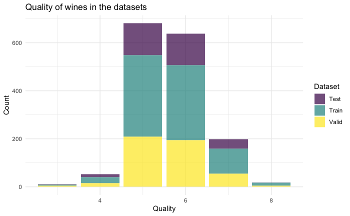

```r
# creating a histogram showing the distribution over dataset
ggplot() +
  geom_bar(data = wine, mapping = aes(x = (quality) , fill = split), alpha = 0.7 )  +
  # getting pretty colours
  scale_fill_viridis_d(name = 'Dataset') +
  labs( # adding labels
    y = 'Count',
    x = 'Quality',
    title = 'Quality of wines in the datasets'
    ) +
  theme_minimal()
```

```r
NA
NA
```

We have chosen to use a subset selection rather than regularisation methods, because we think that limiting the number of columns we use but still allowing for large values in those coefficients will be better than limiting all coefficients. Because, if all coefficients are small, they will likely tend to predict only average qualities rather than also the outliers. Hopefully, with the subset selection, we can cater to the outliers as well.

From here on, the best subset selection method will be implemented.

We use the mse function from lab 4 to get the mean squared error of a certain formula.

```r
lm_mse <- function(formula, train_data, valid_data) {
  y_name <- as.character(formula)[2]
  y_true <- valid_data[[y_name]]

  lm_fit <- lm(formula, train_data)
  y_pred <- predict(lm_fit, newdata = valid_data)

  mean((y_true - y_pred)^2)
}
```

We source the generate_formulas file from Lab 4 to be able to implement the subset selection method.

```r
source("generate_formulas.R")
```

We define the x and y variables to be able to apply the generate_formulas function

```r
wine <- select(wine, -split)
x_vars <- colnames(wine)
x_vars <- x_vars[x_vars != "quality"]
```

We get a vector of all functions.

```r
formulas <- generate_formulas(p = 3, x_vars = x_vars, y_var = "quality")
len <- length(formulas)
```

We use a for loop to find the best set of 3 predictors in the wine dataset based on MSE. Use the wine_train and wine_valid datasets.

```r
# Initialise a vector we will fill with MSE values
mses_3 <- rep(0, len)

# loop over all the formulas
for (i in 1:len) {
  mses_3[i] <- lm_mse(as.formula(formulas[i]), wine_train, wine_valid)
}

# select the formula with the lowest MSE
best_3_preds <- formulas[which.min(mses_3)]
best_3_preds
```

```
[1] "quality ~ volatile.acidity + total.sulfur.dioxide + alcohol"
```

We do the same for 1,2 and 4 predictors.

```r
# generate formulas
formulas_1 <- generate_formulas(p = 1, x_vars = x_vars, y_var = "quality")
formulas_2 <- generate_formulas(p = 2, x_vars = x_vars, y_var = "quality")
formulas_4 <- generate_formulas(p = 4, x_vars = x_vars, y_var = "quality")

# Initialise a vector we will fill with MSE values
mses_1 <- rep(0, length(formulas_1))
mses_2 <- rep(0, length(formulas_2))
mses_4 <- rep(0, length(formulas_4))

# loop over all the formulas
for (i in 1:length(formulas_1)) {
  mses_1[i] <- lm_mse(as.formula(formulas_1[i]), wine_train, wine_valid)
}

for (i in 1:length(formulas_2)) {
  mses_2[i] <- lm_mse(as.formula(formulas_2[i]), wine_train, wine_valid)
}

for (i in 1:length(formulas_4)) {
  mses_4[i] <- lm_mse(as.formula(formulas_4[i]), wine_train, wine_valid)
}

# Compare mses
min(mses_1)
```

```
[1] 0.4957383
```

```r
min(mses_2)
```

```
[1] 0.4332692
```

```r
min(mses_3)
```

```
[1] 0.4280338
```

```r
min(mses_4)
```

```
[1] 0.4215027
```

```r
# min(mses_4) is lowest of them all!
# So let's see which model that is

best_formula <- formulas_4[which.min(mses_4)]
best_formula
```

```
[1] "quality ~ volatile.acidity + chlorides + sulphates + alcohol"
```

We have now found the model with the lowest mean squared error, which we will use to get the optimal model.

```r
# Estimate model and calculate mse
lm_best <- lm(best_formula, data = wine_train)
mse <- function(y_true, y_pred) mean((y_true - y_pred)^2)
mse(wine_test$quality, predict(lm_best, newdata = wine_test))
```

```
[1] 0.420562
```

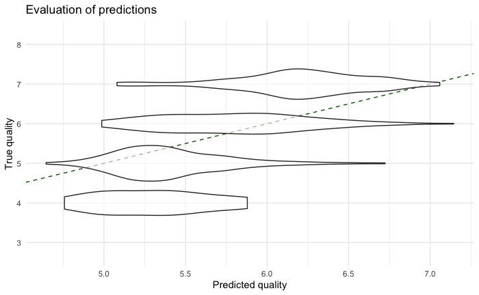

```r
# create a simple scatterplot plot
tibble(
  y_true = wine_test$quality,
  y_pred = predict(lm_best, newdata = wine_test)
) %>%
  ggplot(aes(x = y_pred, y = factor(y_true))) +
  # note that the intercept here is based on the number of categories
  # So like this it creates the line y = x for reference
  geom_abline(slope = 1, intercept = -2, lty = 2, col = 'darkgreen' )+
  geom_violin(orientation = 'y', alpha = 0.6) +
  labs(
    y = 'True quality',
    x = 'Predicted quality',
    title = 'Evaluation of predictions',
    color = 'Fit'
    ) +
  theme_minimal()
```

```r
summary(lm_best)
```

```
Call:
lm(formula = best_formula, data = wine_train)

Residuals:
    Min      1Q  Median      3Q     Max
-2.4336 -0.3536 -0.0637  0.4969  1.9726

Coefficients:
                 Estimate Std. Error t value Pr(>|t|)
(Intercept)       2.35667    0.28413   8.294 4.64e-16 ***
volatile.acidity -1.11717    0.14199  -7.868 1.18e-14 ***
chlorides        -0.84553    0.58554  -1.444    0.149
sulphates         0.95362    0.16607   5.742 1.33e-08 ***
alcohol           0.31828    0.02294  13.875  < 2e-16 ***
---
Signif. codes:  0 ‘***’ 0.001 ‘**’ 0.01 ‘*’ 0.05 ‘.’ 0.1 ‘ ’ 1

Residual standard error: 0.6653 on 795 degrees of freedom
Multiple R-squared:  0.3529,    Adjusted R-squared:  0.3496
F-statistic: 108.4 on 4 and 795 DF,  p-value: < 2.2e-16
```

In conclusion, the quality of the wine can be predicted to some extent by the volatile acidity, chlorides, sulphates and alcohol level in the wine. We see that lower acidity means a higher quality, while higher sulphate and alcohol levels are also indicators of a higher quality wine. Chlorides actually don’t significantly predict the quality, but did lower the mean squared error, which is why it’s still included. So, next time you’re standing in the supermarket looking for a good but cheap wine, taking the alcohol level as an indicator is actually a good idea!